# **Machine Learning Bonus Project:** Air quality in regions of the world

#### Major: DIA (2)

## Table of Content (Clickable)

- 0. Presentation of the topic and contextualization
- 1. Description and formalization of the problem
- 2. Preprocessing
  - 1) Package installation
  - 2) Libraries import
  - 3) Data Inspection and Cleaning
    - (i) Data import
    - (ii) Data Exploration
    - (iii) Missing values
    - (iv) Mapping the data
    - (v) Unique values
    - (vi) Outliers visualization
    - (vii) Useless features
    - (viii) Re-Writing Data
    - (ix) Dividing columns into groups
- 3. Understanding the Data
- 4. Solutions and Arguments for the Choice of Machine Learning Algorithms
- 5. Experimentation and Discussion of the Results
  - Part I : Classification
  - DecisionTreeClassifier
  - Gini criteria
  - Entropy criteria
  - Finding the best criteria
  - K-Means
  - Doing logistic regression
  - Comparison side by side
  - PCA's impact
  - Part II : Regression
  - Plot the most correlated with PCA
  - Gridsearch
- 6. Group Assessment

# Presentation of the Topic and Contextualization

## Air Quality Index (AQI)

An Air Quality Index (AQI) is utilized to communicate the current level of air pollution to the general public, as well as forecast future pollution levels. To measure it, we measure multiple components, that are provided in this dataset. The problem, of course, is that the AQI is not good in every region of the world, and nowadays news keep us thinking that it is never going to be improved at our rate. By studying this dataset, we wand to show that it is possible to reduce the global impact by pollutants by decentralizing ourselves from the city. Of course, all of this is pretty theoritical, and our main manoeuvre here is to target the AQI to see if we can predict it with less components, we will talk about that in the Description of the problem. This dataset also provides geolocated information about the following pollutants:

## Nitrogen Dioxide [NO2]

Nitrogen Dioxide is one of several nitrogen oxides. It enters the air through natural phenomena, such as stratospheric entry or lightning. However, at ground level, NO2 primarily forms from emissions of cars, trucks, buses, power plants, and off-road equipment. Short-term exposure can worsen respiratory diseases, such as asthma, while longer exposures may contribute to the development of asthma and respiratory infections. People with asthma, children, and the elderly are at higher risk of NO2-related health effects.

## Ozone [O3]

The Ozone molecule is harmful for outdoor air quality (if outside of the ozone layer). At ground level, ozone is created through chemical reactions between nitrogen oxides and volatile organic compounds (VOCs). Unlike the beneficial ozone found in the upper atmosphere, ground-level ozone can cause a range of health problems, including chest pain, coughing, throat irritation, and airway inflammation. It can also reduce lung function and worsen conditions like bronchitis, emphysema, and asthma. Additionally, ozone negatively affects vegetation and ecosystems, particularly by damaging sensitive plants during the growing season.

## Carbon Monoxide [CO]

Carbon Monoxide is a colorless and odorless gas. It is primarily emitted into the outdoor air by cars, trucks, and other vehicles or machinery that burn fossil fuels. Indoor sources of CO include kerosene and gas space heaters, as well as gas stoves, which can degrade indoor air quality. Breathing air with high concentrations of CO reduces the amount of oxygen that can be transported in the bloodstream to critical organs like the heart and brain. At very high levels, which are unlikely to occur outdoors but possible in enclosed environments, CO can cause dizziness, confusion, unconsciousness, and even death.

## Particulate Matter [PM2.5]

Atmospheric Particulate Matter, also known as atmospheric aerosol particles, is a complex mixture of small solid and liquid matter that becomes suspended in the air. When inhaled, these particles can cause serious heart and lung problems. They have been classified as group 1 carcinogens by the International Agency for Research on Cancer (IARC). PM10 refers to particles with a diameter of 10 micrometers or less, while PM2.5 refers to particles with a diameter of 2.5 micrometers or less.

# Description and Formalization of the Problem

"What you can't measure is what you can't improve" - Kelvin

There is a problem about **AQI measures**, and we will try to provide *solutions* to them. First, the problem we will try to solve is the **cost of measurement**, then, we will talk about the covering space of these measures. To keep introducing our subject, we will then observe the dataset provided and enounce our overview on it.

## Cost of the Measurement

Getting the **AQI values** of areas of the world can be an *interesting measurement*, because it could be helpful to know where we could build pollutant spaces without turning the air toxic or unbreathable. On the other hand, there are also areas that are simply naturally polluted and can't be used to be built on (i.e: obviously a volcano is not the perfect site to build a city, but there are less noticable areas that are naturally enticed to pollution). The problem is that getting the AQI value is requiring the measurement of **four different pollutants**, and each of them has a different scientific protocol to measure it. These protocols cost a lot: sometimes we talk about tens of thousands of dollars for on pollutant. Our study has the objective to find out if there are pollutants that share a bigger part in the AQI value, and if we could get rid of the others that necessitate **big sums of money**. Also, we will focus on the components that can be measured with the same means, so that *one stone will kill two birds*.

## Impact on the World Crisis

With **lower measurement cost**, it could be easily envisageable to cover more ground and have a bigger overview of the world's AQI. Even though it is not one of the most important criteria companies and countries look over when they want to build, we tend in a world where breathable air will become central (i.e: in China, they pay to breath neutral air with a price per minute). For countries that have big unexploited spaces (like *France: La diagonale du vide*), it might be a new criteria, and a lower cost of measurement will make it more accessible.

# Preprocessing

## Data Preprocessing Overview

Our preprocessing follows these basic stages:

- **Package Installation:** Setting up the necessary tools.
- **Libraries Import:** Bringing in required libraries.
- **Data Inspection and Cleaning:** Examining and refining the dataset.

Once these stages are passed, we will have our data ready for tests and machine learning algorithms. Understanding the data is crucial, which is why we plot information, like noticing that *the United States is the most well-represented country in the dataset*, impacting the precision of results.

### Ensuring Data Readiness

To make sure our data is ready to be used, we will go through these steps:

1. Removing Missing Values
2. Mapping the Data
3. Exploring Unique Values
4. Removing Outliers and Useless Features
5. Re-Writing Data
6. Dividing Some Columns into Groups

This is a comprehensive preprocessing approach, necessary to explore our results correctly.

### 1) Package installation

```python
#!pip install sklearn
```

### 2) Libraries Import

```python
import numpy as np
import pandas as pd
import matplotlib.pyplot as plt
import seaborn as sns

from sklearn.model_selection import train_test_split, cross_val_score, KFold
from sklearn.linear_model import LinearRegression, Ridge, Lasso, LogisticRegression
from sklearn.tree import DecisionTreeRegressor, DecisionTreeClassifier, plot_tree
from sklearn.ensemble import RandomForestRegressor, GradientBoostingRegressor, RandomForestClassifier
from sklearn.metrics import mean_squared_error, accuracy_score, classification_report, confusion_matrix
from sklearn.preprocessing import StandardScaler
from sklearn.pipeline import Pipeline, make_pipeline
from sklearn.cluster import KMeans
from sklearn.decomposition import PCA
```

```python
import warnings
warnings.filterwarnings('ignore')
```

### 3) Data Inspection and Cleaning

```python
def make_basic_overview(data):
    border = 12*'='

    print(border, 'Basic Info', border)
    data.info()
    print('\n\n')

    print(border, 'First Five Rows', border)
    display(data.head())
    print('\n\n')

    print(border, 'Last Five Rows', border)
    display(data.tail())
    print('\n\n')

    print(border, 'Duplicates', border)
    print()
    if data.duplicated().sum() > 0:
        print(f'Amount of duplicated rows: {data.duplicated().sum()}.')
        data.drop_duplicates(inplace=True, ignore_index=True)
        print('Duplicated rows were dropped.')
    else:
        print('None.')
```

```python
def make_df_dtype(data):
    cols, dtype_col, specimens, nunique, null_share = [], [], [], [], []
    for column in data:
        cols.append(column)

        this_dtype = data[column].dtype
        dtype_col.append(this_dtype)

        specimen = data.loc[data[column].first_valid_index(), column]
        specimens.append(specimen)

        nunique.append(data[column].nunique())

        null_sum = data[column].isna().sum()
        null_to_len = null_sum / len(data[column])
        null_share.append(f'{null_to_len:.2%}')

    df = pd.DataFrame(list(zip(dtype_col,
                               specimens,
                               nunique,
                              null_share)),
                      index=cols)
    df.columns=['dtype',
                'specimen',
                'nunique',
               'null_share']

    return df
```

#### (i) Data Import

```python
data=pd.read_csv('AQI_values_countries.csv')
data=pd.DataFrame(data)
```

#### (ii) Data Exploration

```python
data.head(5)
```

|  | Country | City | AQI Value | AQI Category | CO AQI Value | CO AQI Category | Ozone AQI Value | Ozone AQI Category | NO2 AQI Value | NO2 AQI Category | PM2.5 AQI Value | PM2.5 AQI Category |
| --- | --- | --- | --- | --- | --- | --- | --- | --- | --- | --- | --- | --- |
| 0 | Russian Federation | Praskoveya | 51 | Moderate | 1 | Good | 36 | Good | 0 | Good | 51 | Moderate |
| 1 | Brazil | Presidente Dutra | 41 | Good | 1 | Good | 5 | Good | 1 | Good | 41 | Good |
| 2 | Italy | Priolo Gargallo | 66 | Moderate | 1 | Good | 39 | Good | 2 | Good | 66 | Moderate |
| 3 | Poland | Przasnysz | 34 | Good | 1 | Good | 34 | Good | 0 | Good | 20 | Good |
| 4 | France | Punaauia | 22 | Good | 0 | Good | 22 | Good | 0 | Good | 6 | Good |

```python
print("Number of Lines", data.shape[0])
print("Number of Columns", data.shape[1])
```

```
Number of Lines 23463
Number of Columns 12
```

```python
make_basic_overview(data)
```

```
============ Basic Info ============
<class 'pandas.core.frame.DataFrame'>
RangeIndex: 23463 entries, 0 to 23462
Data columns (total 12 columns):
 #   Column              Non-Null Count  Dtype
---  ------              --------------  -----
 0   Country             23036 non-null  object
 1   City                23462 non-null  object
 2   AQI Value           23463 non-null  int64
 3   AQI Category        23463 non-null  object
 4   CO AQI Value        23463 non-null  int64
 5   CO AQI Category     23463 non-null  object
 6   Ozone AQI Value     23463 non-null  int64
 7   Ozone AQI Category  23463 non-null  object
 8   NO2 AQI Value       23463 non-null  int64
 9   NO2 AQI Category    23463 non-null  object
 10  PM2.5 AQI Value     23463 non-null  int64
 11  PM2.5 AQI Category  23463 non-null  object
dtypes: int64(5), object(7)
memory usage: 2.1+ MB



============ First Five Rows ============
```

|  | Country | City | AQI Value | AQI Category | CO AQI Value | CO AQI Category | Ozone AQI Value | Ozone AQI Category | NO2 AQI Value | NO2 AQI Category | PM2.5 AQI Value | PM2.5 AQI Category |
| --- | --- | --- | --- | --- | --- | --- | --- | --- | --- | --- | --- | --- |
| 0 | Russian Federation | Praskoveya | 51 | Moderate | 1 | Good | 36 | Good | 0 | Good | 51 | Moderate |
| 1 | Brazil | Presidente Dutra | 41 | Good | 1 | Good | 5 | Good | 1 | Good | 41 | Good |
| 2 | Italy | Priolo Gargallo | 66 | Moderate | 1 | Good | 39 | Good | 2 | Good | 66 | Moderate |
| 3 | Poland | Przasnysz | 34 | Good | 1 | Good | 34 | Good | 0 | Good | 20 | Good |
| 4 | France | Punaauia | 22 | Good | 0 | Good | 22 | Good | 0 | Good | 6 | Good |

```
============ Last Five Rows ============
```

|  | Country | City | AQI Value | AQI Category | CO AQI Value | CO AQI Category | Ozone AQI Value | Ozone AQI Category | NO2 AQI Value | NO2 AQI Category | PM2.5 AQI Value | PM2.5 AQI Category |
| --- | --- | --- | --- | --- | --- | --- | --- | --- | --- | --- | --- | --- |
| 23458 | India | Gursahaiganj | 184 | Unhealthy | 3 | Good | 154 | Unhealthy | 2 | Good | 184 | Unhealthy |
| 23459 | France | Sceaux | 50 | Good | 1 | Good | 20 | Good | 5 | Good | 50 | Good |
| 23460 | India | Mormugao | 50 | Good | 1 | Good | 22 | Good | 1 | Good | 50 | Good |
| 23461 | United States of America | Westerville | 71 | Moderate | 1 | Good | 44 | Good | 2 | Good | 71 | Moderate |
| 23462 | Malaysia | Marang | 70 | Moderate | 1 | Good | 38 | Good | 0 | Good | 70 | Moderate |

```
============ Duplicates ============

None.
```

#### (iii) Missing Values

```python
missing_values = data.isna().sum()
missing_percentage = (missing_values / len(data)) * 100
print(missing_percentage)
```

```
Country               1.819887
City                  0.004262
AQI Value             0.000000
AQI Category          0.000000
CO AQI Value          0.000000
CO AQI Category       0.000000
Ozone AQI Value       0.000000
Ozone AQI Category    0.000000
NO2 AQI Value         0.000000
NO2 AQI Category      0.000000
PM2.5 AQI Value       0.000000
PM2.5 AQI Category    0.000000
dtype: float64
```

```python
missing_samples = data[data.isnull().any(axis=1)].head(20)
print(missing_samples)
```

```
     Country                City  AQI Value                    AQI Category  \
535      NaN           Granville         30                            Good
654      NaN  Kingston Upon Hull         33                            Good
787      NaN       New Waterford         20                            Good
801      NaN           Kingstown        163                       Unhealthy
906      NaN            Nanakuli         30                            Good
916      NaN             Lavagna         55                        Moderate
968      NaN           Ladispoli         48                            Good
985      NaN            Dong Hoi         55                        Moderate
1139     NaN             Nettuno         53                        Moderate
1169     NaN         Puebloviejo         71                        Moderate
1247     NaN           Fiumicino         51                        Moderate
1474     NaN         Nishinomiya         56                        Moderate
1550     NaN            Carteret         56                        Moderate
1609     NaN            Ercolano         48                            Good
```

[output cut: 72 more lines]

```python
make_df_dtype(data)
```

|  | dtype | specimen | nunique | null_share |
| --- | --- | --- | --- | --- |
| Country | object | Russian Federation | 175 | 1.82% |
| City | object | Praskoveya | 23462 | 0.00% |
| AQI Value | int64 | 51 | 347 | 0.00% |
| AQI Category | object | Moderate | 6 | 0.00% |
| CO AQI Value | int64 | 1 | 34 | 0.00% |
| CO AQI Category | object | Good | 3 | 0.00% |
| Ozone AQI Value | int64 | 36 | 213 | 0.00% |
| Ozone AQI Category | object | Good | 5 | 0.00% |
| NO2 AQI Value | int64 | 0 | 59 | 0.00% |
| NO2 AQI Category | object | Good | 2 | 0.00% |
| PM2.5 AQI Value | int64 | 51 | 383 | 0.00% |
| PM2.5 AQI Category | object | Moderate | 6 | 0.00% |

#### (iv) Mapping the data

```python
category_mappings = {
    'PM2.5 AQI Category': {
        'Good': 1,
        'Moderate': 2,
        'Unhealthy for Sensitive Groups': 3,
        'Unhealthy': 4,
        'Very Unhealthy': 5,
        'Hazardous': 6
    },
    'NO2 AQI Category': {
        'Good': 1,
        'Moderate': 2
    },
    'Ozone AQI Category': {
        'Good': 1,
        'Moderate': 2,
        'Unhealthy for Sensitive Groups': 3,
        'Unhealthy': 4,
        'Very Unhealthy': 5
    },
    'CO AQI Category': {
        'Good': 1,
        'Moderate': 2,
        'Unhealthy for Sensitive Groups': 3
    },
    'AQI Category': {
        'Good': 1,
        'Moderate': 2,
        'Unhealthy for Sensitive Groups': 3,
        'Unhealthy': 4,
        'Very Unhealthy': 5,
        'Hazardous': 6
    }
}
```

#### (v) Unique Values

```python
colonnes=['Country','City','AQI Value','AQI Category','CO AQI Value','CO AQI Category',
         'Ozone AQI Value','NO2 AQI Value','NO2 AQI Category','PM2.5 AQI Value','PM2.5 AQI Category']

for colonne in colonnes:
    valeurs_uniques = data[colonne].unique()
    print("Colonnes :", colonne)
    print("Différentes valeurs uniques :")
    print(valeurs_uniques)
    print()
```

```
Colonnes : Country
Différentes valeurs uniques :
['Russian Federation' 'Brazil' 'Italy' 'Poland' 'France'
 'United States of America' 'Germany' 'Belgium' 'Egypt' 'China'
 'Netherlands' 'India' 'Pakistan' 'Republic of North Macedonia' 'Colombia'
 'Romania' 'Indonesia' 'Finland' 'South Africa'
 'United Kingdom of Great Britain and Northern Ireland'
 'United Republic of Tanzania' 'Haiti' 'Somalia' 'Philippines' 'Latvia'
 'Chad' 'New Zealand' 'Tunisia' 'Viet Nam' 'Iran (Islamic Republic of)'
 'Mexico' 'Japan' 'El Salvador' 'Bulgaria' 'Nigeria' 'South Sudan'
 'Guatemala' 'Ireland' 'Turkey' 'Peru' 'Democratic Republic of the Congo'
 'Canada' 'Switzerland' 'Denmark' 'Cameroon' 'Australia' 'Portugal'
 "Côte d'Ivoire" 'Sweden' 'Ethiopia' 'Thailand' 'Hungary' 'Kazakhstan'
 'Israel' 'Spain' 'Myanmar' 'Papua New Guinea' 'Madagascar' 'Lithuania'
 'Ghana' 'Azerbaijan' 'Armenia' 'Ukraine' 'Malaysia' 'Serbia' 'Slovakia'
 'Gambia' 'Ecuador' 'Bosnia and Herzegovina' 'Czechia' 'Argentina'
 'Dominican Republic' 'Guinea' 'Bolivia (Plurinational State of)'
 'Bangladesh' 'Sudan' 'Chile' 'Panama' 'Congo' 'Kyrgyzstan' 'Mauritius'
 'Greece' 'Malawi' 'Cuba' 'Saudi Arabia' 'Benin' 'Sierra Leone' 'Lebanon'
 'Uruguay' 'Namibia' 'Albania' nan 'Guyana' 'Senegal' 'Lesotho' 'Mongolia'
 'Venezuela (Bolivarian Republic of)' 'Solomon Islands' 'Paraguay'
 'Zimbabwe' 'Austria' 'Croatia' 'Honduras' 'Cambodia' 'Uganda'
 'Republic of Moldova' 'Angola' 'Kingdom of Eswatini' 'Afghanistan'
 'Uzbekistan' 'Zambia' 'Morocco' 'Belarus' 'Norway' 'Malta' 'Rwanda'
 'Sri Lanka' 'Botswana' 'Burundi' 'Jamaica' 'Central African Republic'
 'Kenya' 'Niger' 'Mali' 'Slovenia' 'Costa Rica' 'Nicaragua'
 'Republic of Korea' 'Burkina Faso' 'Cabo Verde' 'Mozambique' 'Mauritania'
 'Guinea-Bissau' 'United Arab Emirates' 'Eritrea' 'Tajikistan' 'Barbados'
 'Algeria' 'Iraq' 'Syrian Arab Republic' 'Gabon' 'Liberia'
 "Lao People's Democratic Republic" 'Bhutan' 'Yemen' 'Togo' 'Turkmenistan'
 'Saint Lucia' 'Kuwait' 'Libya' 'Georgia' 'Nepal' 'Estonia'
 'Trinidad and Tobago' 'Jordan' 'Cyprus' 'Montenegro' 'Comoros' 'Iceland'
 'Andorra' 'Oman' 'Equatorial Guinea' 'Luxembourg' 'Vanuatu' 'Aruba'
 'Belize' 'Qatar' 'Palau' 'Suriname' 'Singapore' 'Maldives' 'Bahrain'
 'Seychelles' 'State of Palestine' 'Saint Kitts and Nevis' 'Monaco']

Colonnes : City
Différentes valeurs uniques :
['Praskoveya' 'Presidente Dutra' 'Priolo Gargallo' ... 'Mormugao'
 'Westerville' 'Marang']
```

[output cut: 77 more lines]

```
 264 116 218 141 178 113 137 415  96 123 235 201 134 437 204 210 279 131
 196 199 181 433 236 183 224 283   4 467 297 240 372 378 296 295 239 276
 241 480 334 271 211 214 228   2 135 305 242 308 219 238 244 205 136 147
 232 328 207 320 332 225 220 177 396 281 212 233 254 446 248 324 461 275
 245 221 479 249 280 412 420 298 476 321 227 274 374 470 329 384 492 358
 286 416 496 282 277 234 331 206 353 441 256 311 231 370 216 428 481 268
 361 490 229 319 382 215 339 457 285 269 454 477 266 472 310 450 474 327
 379 403 223 325 471 460 246 203 259 250 257 255 341 350 252 411 300 383
 355 263 487 456 243 237 200 442 270 424 398   0 392 452 267 494 262 475
 369 251 407 447 253]

Colonnes : PM2.5 AQI Category
Différentes valeurs uniques :
['Moderate' 'Good' 'Unhealthy for Sensitive Groups' 'Unhealthy'
 'Very Unhealthy' 'Hazardous']
```

```python
data_cleaned = data.copy()

for column, mapping in category_mappings.items():
    if column in data.columns:
        print(column)
        print(mapping)
        print(data_cleaned[column].unique())
        data_cleaned[column] = data_cleaned[column].map(mapping)

data_cleaned
```

```
PM2.5 AQI Category
{'Good': 1, 'Moderate': 2, 'Unhealthy for Sensitive Groups': 3, 'Unhealthy': 4, 'Very Unhealthy': 5, 'Hazardous': 6}
['Moderate' 'Good' 'Unhealthy for Sensitive Groups' 'Unhealthy'
 'Very Unhealthy' 'Hazardous']
NO2 AQI Category
{'Good': 1, 'Moderate': 2}
['Good' 'Moderate']
Ozone AQI Category
{'Good': 1, 'Moderate': 2, 'Unhealthy for Sensitive Groups': 3, 'Unhealthy': 4, 'Very Unhealthy': 5}
['Good' 'Moderate' 'Unhealthy for Sensitive Groups' 'Unhealthy'
 'Very Unhealthy']
CO AQI Category
{'Good': 1, 'Moderate': 2, 'Unhealthy for Sensitive Groups': 3}
['Good' 'Unhealthy for Sensitive Groups' 'Moderate']
AQI Category
{'Good': 1, 'Moderate': 2, 'Unhealthy for Sensitive Groups': 3, 'Unhealthy': 4, 'Very Unhealthy': 5, 'Hazardous': 6}
['Moderate' 'Good' 'Unhealthy for Sensitive Groups' 'Unhealthy'
 'Very Unhealthy' 'Hazardous']
```

|  | Country | City | AQI Value | AQI Category | CO AQI Value | CO AQI Category | Ozone AQI Value | Ozone AQI Category | NO2 AQI Value | NO2 AQI Category | PM2.5 AQI Value | PM2.5 AQI Category |
| --- | --- | --- | --- | --- | --- | --- | --- | --- | --- | --- | --- | --- |
| 0 | Russian Federation | Praskoveya | 51 | 2 | 1 | 1 | 36 | 1 | 0 | 1 | 51 | 2 |
| 1 | Brazil | Presidente Dutra | 41 | 1 | 1 | 1 | 5 | 1 | 1 | 1 | 41 | 1 |
| 2 | Italy | Priolo Gargallo | 66 | 2 | 1 | 1 | 39 | 1 | 2 | 1 | 66 | 2 |
| 3 | Poland | Przasnysz | 34 | 1 | 1 | 1 | 34 | 1 | 0 | 1 | 20 | 1 |
| 4 | France | Punaauia | 22 | 1 | 0 | 1 | 22 | 1 | 0 | 1 | 6 | 1 |
| ... | ... | ... | ... | ... | ... | ... | ... | ... | ... | ... | ... | ... |
| 23458 | India | Gursahaiganj | 184 | 4 | 3 | 1 | 154 | 4 | 2 | 1 | 184 | 4 |
| 23459 | France | Sceaux | 50 | 1 | 1 | 1 | 20 | 1 | 5 | 1 | 50 | 1 |
| 23460 | India | Mormugao | 50 | 1 | 1 | 1 | 22 | 1 | 1 | 1 | 50 | 1 |
| 23461 | United States of America | Westerville | 71 | 2 | 1 | 1 | 44 | 1 | 2 | 1 | 71 | 2 |
| 23462 | Malaysia | Marang | 70 | 2 | 1 | 1 | 38 | 1 | 0 | 1 | 70 | 2 |

23463 rows × 12 columns

#### (vi) Outliers visualization

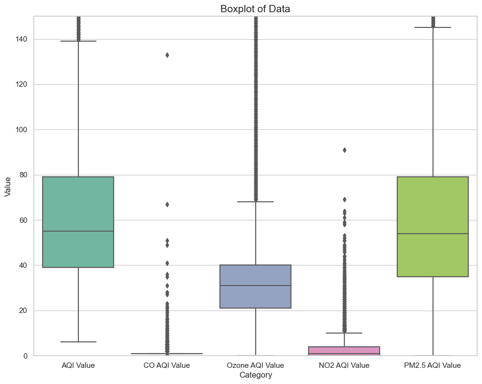

```python
sns.set(style="whitegrid")

plt.figure(figsize=(10, 8))
sns.boxplot(data=data, palette="Set2")

plt.title('Boxplot of Data', fontsize=15)
plt.ylabel('Value', fontsize=12)
plt.xlabel('Category', fontsize=12)
plt.ylim(0, 150)

plt.tight_layout()
plt.show()
```

#### (vii) Useless features

```python
data_cleaned = data_cleaned.dropna()
```

```python
missing_country_cities = data_cleaned[data_cleaned['Country'].isna()]['City'].unique()

print(f"We've got {len(missing_country_cities)} cities without a stated country.")
print('For instance:')
for city in missing_country_cities[:15]:
    print(f'- {city}')
```

```
We've got 0 cities without a stated country.
For instance:
```

#### (viii) Re-writting Data

```python
data_cleaned.columns = (
    data_cleaned
    .columns
    .str.lower()
    .str.replace(' ', '_', regex=False)
    .str.replace('.', '_', regex=False)
)

data_cleaned.columns
```

```
Index(['country', 'city', 'aqi_value', 'aqi_category', 'co_aqi_value',
       'co_aqi_category', 'ozone_aqi_value', 'ozone_aqi_category',
       'no2_aqi_value', 'no2_aqi_category', 'pm2_5_aqi_value',
       'pm2_5_aqi_category'],
      dtype='object')
```

```python
data.columns = (
    data
    .columns
    .str.lower()
    .str.replace(' ', '_', regex=False)
    .str.replace('.', '_', regex=False)
)

data.columns
```

```
Index(['country', 'city', 'aqi_value', 'aqi_category', 'co_aqi_value',
       'co_aqi_category', 'ozone_aqi_value', 'ozone_aqi_category',
       'no2_aqi_value', 'no2_aqi_category', 'pm2_5_aqi_value',
       'pm2_5_aqi_category'],
      dtype='object')
```

#### (ix) Dividing columns into groups

```python
data_dict = dict()

num_cols_list = data_cleaned.select_dtypes(include='number').columns.to_list()
str_cols_list = data_cleaned.select_dtypes(include='object').columns.to_list()

str_cols_list.remove('country')
str_cols_list.remove('city')

data_dict['str_cols_list'] = str_cols_list
data_dict['num_cols_list'] = num_cols_list

print('Non-numeric values:')
display(data_dict['str_cols_list'])
print('\nNumeric values:')
display(data_dict['num_cols_list'])
```

```
Non-numeric values:
```

```
[]
```

```
Numeric values:
```

```
['aqi_value',
 'aqi_category',
 'co_aqi_value',
 'co_aqi_category',
 'ozone_aqi_value',
 'ozone_aqi_category',
 'no2_aqi_value',
 'no2_aqi_category',
 'pm2_5_aqi_value',
 'pm2_5_aqi_category']
```

# Understanding the Data

```python
def numeric_cols_hist(data, width, height):
    '''
    Plot histograms for all columns with numeric values.
    '''
    cols = data.select_dtypes(include=('number')).columns.to_list()
    data[cols].hist(bins=30, figsize=(width, height))
    plt.show()
    print('Here, the density of values in each numeric column is shown.')

column_description = [
    ['aqi', 'air quality index (AQI)', 'Air quality index (AQI): shows how polluted the air currently is\nor how polluted it is forecast to become.'],
    ['co_aqi', 'carbon monoxide (CO)', 'Carbon Monoxide is a colorless and odorless gas.\nOutdoor, it is emitted in the air above all by cars,\ntrucks and other vehicles or machineries that burn fossil fuels.'],
    ['ozone_aqi', 'ozone (O3)', 'Ground level ozone can provoke several health problems like chest pain,\ncoughing, throat irritation and airway inflammation.'],
    ['no2_aqi', 'nitrogen dioxide (NO2)', 'At the surface level, NO2 forms from cars, trucks and buses emissions,\npower plants and off-road equipment.\nExposures may contribute to develoment of asthma and respiratory infections.'],
    ['pm2_5_aqi', 'atmospheric particulate matter (PM2.5)', 'Atmospheric Particulate Matter, also known as atmospheric aerosol particles,\nare complex mixtures of small solid and liquid matter that get into the air.\nIf inhaled they can cause serious heart and lungs problem.']
              ]
```

```python
def make_heatmap_cities_per_countries_and_categories(
    data,
    list_of_countries,
    category_column,
    ylabel,
    xlabel,
    plttitle,
    palette
):
    df = data[data['country'].isin(list_of_countries)].copy()

    category_order = ['Good', 'Moderate', 'Unhealthy for Sensitive Groups', 'Unhealthy', 'Very Unhealthy', 'Hazardous']
    df[category_column] = pd.Categorical(df[category_column], categories=category_order, ordered=True)

    this_crosstab = pd.crosstab(
        index=df['country'],
        columns=df[category_column],
        values=df['city'],
        aggfunc='count',
        normalize='index'
    )

    #Heatmap
    sns.heatmap(
        this_crosstab.sort_values(by='Good', ascending=False),
        cmap=palette,
        annot=True,
        fmt='.2%',
        linecolor='#959595',
        linewidths=.75,
        cbar=False
    )
    plt.ylabel(ylabel)
    plt.xlabel(xlabel)
    plt.xticks(rotation=45, ha='right')
    plt.title(plttitle, fontsize=25, loc='left')
    plt.show()
```

```python
sns.set(rc={'figure.figsize': (9, 6)})

pd.options.mode.chained_assignment = None

colour = '#748881'
```

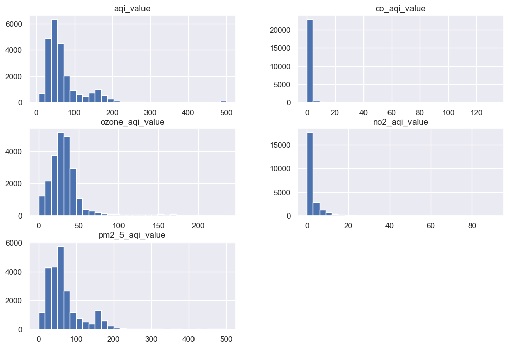

```
Here, the density of values in each numeric column is shown.
```

```python
numeric_cols_hist(data, width=12, height=8)
```

```python
data_cleaned.columns
```

```
Index(['country', 'city', 'aqi_value', 'aqi_category', 'co_aqi_value',
       'co_aqi_category', 'ozone_aqi_value', 'ozone_aqi_category',
       'no2_aqi_value', 'no2_aqi_category', 'pm2_5_aqi_value',
       'pm2_5_aqi_category'],
      dtype='object')
```

```python
(
    data_cleaned
    .groupby('country')
    ['aqi_category'].count()
    .describe()
)
```

```
count     175.000000
mean      131.628571
std       355.830394
min         1.000000
25%        10.500000
50%        28.000000
75%        80.500000
max      2872.000000
Name: aqi_category, dtype: float64
```

Almost half of the countries within this dataset are mentioned in 30 entries or less than that.

Three-quarters are mentioned in 80 rows or less than that.

There is at least one country that has almost 3000 rows. Let's see.

```python
for pair in [
    ['Republic of North Macedonia', 'North Macedonia'],
    ['Iran (Islamic Republic of)', 'Iran'],
    ['Bolivia (Plurinational State of)', 'Bolivia'],
    ['Venezuela (Bolivarian Republic of)', 'Venezuela'],
    ['United Arab Emirates', 'UAE'],
    ['Syrian Arab Republic', 'Syria'],
    ['Russian Federation', 'Russia'],
    ['United Kingdom of Great Britain and Northern Ireland', 'UK'],
    ['United States of America', 'USA'],
    ['State of Palestine', 'Palestine'],
    ['Central African Republic', 'CAR'],
    ['Republic of Korea', 'South Korea'],
    ['Democratic Republic of the Congo', 'DRC'],
    ['Laos', "Lao People's Democratic Republic"],
    ['Kingdom of Eswatini', 'Eswatini'],
    ['United Republic of Tanzania', 'Tanzania']
]:
    data['country'] = data['country'].replace(pair[0], pair[1], regex=False)
    data_cleaned['country'] = data_cleaned['country'].replace(pair[0], pair[1], regex=False)
```

```python
data_cleaned['country'].unique()
```

```
array(['Russia', 'Brazil', 'Italy', 'Poland', 'France', 'USA', 'Germany',
       'Belgium', 'Egypt', 'China', 'Netherlands', 'India', 'Pakistan',
       'North Macedonia', 'Colombia', 'Romania', 'Indonesia', 'Finland',
       'South Africa', 'UK', 'Tanzania', 'Haiti', 'Somalia',
       'Philippines', 'Latvia', 'Chad', 'New Zealand', 'Tunisia',
       'Viet Nam', 'Iran', 'Mexico', 'Japan', 'El Salvador', 'Bulgaria',
       'Nigeria', 'South Sudan', 'Guatemala', 'Ireland', 'Turkey', 'Peru',
       'DRC', 'Canada', 'Switzerland', 'Denmark', 'Cameroon', 'Australia',
       'Portugal', "Côte d'Ivoire", 'Sweden', 'Ethiopia', 'Thailand',
       'Hungary', 'Kazakhstan', 'Israel', 'Spain', 'Myanmar',
       'Papua New Guinea', 'Madagascar', 'Lithuania', 'Ghana',
       'Azerbaijan', 'Armenia', 'Ukraine', 'Malaysia', 'Serbia',
       'Slovakia', 'Gambia', 'Ecuador', 'Bosnia and Herzegovina',
       'Czechia', 'Argentina', 'Dominican Republic', 'Guinea', 'Bolivia',
       'Bangladesh', 'Sudan', 'Chile', 'Panama', 'Congo', 'Kyrgyzstan',
       'Mauritius', 'Greece', 'Malawi', 'Cuba', 'Saudi Arabia', 'Benin',
       'Sierra Leone', 'Lebanon', 'Uruguay', 'Namibia', 'Albania',
       'Guyana', 'Senegal', 'Lesotho', 'Mongolia', 'Venezuela',
       'Solomon Islands', 'Paraguay', 'Zimbabwe', 'Austria', 'Croatia',
       'Honduras', 'Cambodia', 'Uganda', 'Republic of Moldova', 'Angola',
       'Eswatini', 'Afghanistan', 'Uzbekistan', 'Zambia', 'Morocco',
       'Belarus', 'Norway', 'Malta', 'Rwanda', 'Sri Lanka', 'Botswana',
       'Burundi', 'Jamaica', 'CAR', 'Kenya', 'Niger', 'Mali', 'Slovenia',
       'Costa Rica', 'Nicaragua', 'South Korea', 'Burkina Faso',
       'Cabo Verde', 'Mozambique', 'Mauritania', 'Guinea-Bissau', 'UAE',
       'Eritrea', 'Tajikistan', 'Barbados', 'Algeria', 'Iraq', 'Syria',
       'Gabon', 'Liberia', "Lao People's Democratic Republic", 'Bhutan',
       'Yemen', 'Togo', 'Turkmenistan', 'Saint Lucia', 'Kuwait', 'Libya',
       'Georgia', 'Nepal', 'Estonia', 'Trinidad and Tobago', 'Jordan',
       'Cyprus', 'Montenegro', 'Comoros', 'Iceland', 'Andorra', 'Oman',
       'Equatorial Guinea', 'Luxembourg', 'Vanuatu', 'Aruba', 'Belize',
       'Qatar', 'Palau', 'Suriname', 'Singapore', 'Maldives', 'Bahrain',
       'Seychelles', 'Palestine', 'Saint Kitts and Nevis', 'Monaco'],
      dtype=object)
```

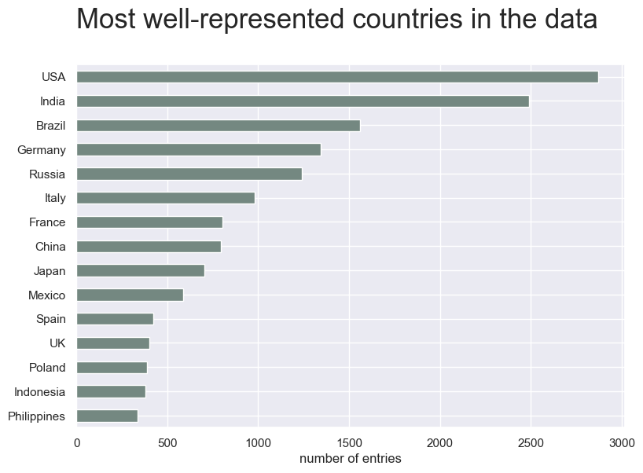

```python
(
    data
    .groupby('country')
    ['aqi_category'].count()
    .sort_values(ascending=False)
    .head(15)
    .sort_values(ascending=True)
    .plot(kind='barh', color=colour)
)
plt.title('Most well-represented countries in the data\n', loc='left', fontsize=25)
plt.ylabel('')
plt.xlabel('number of entries')
plt.show()
```

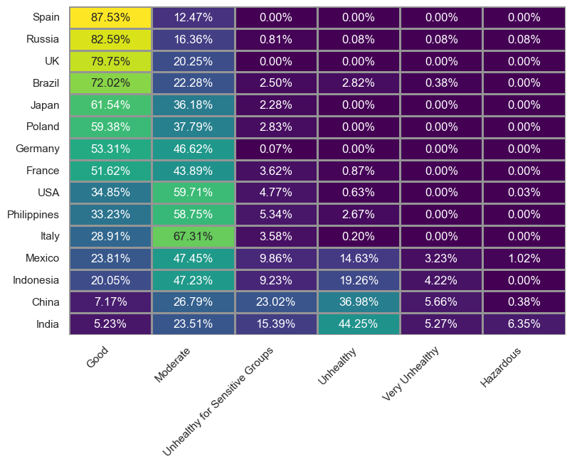

```python
top_list = (data.groupby('country')
               ['aqi_category'].count()
               .sort_values(ascending=False)
               .head(15)
               .index
               .to_list())

make_heatmap_cities_per_countries_and_categories(
    data=data,
    list_of_countries=top_list,
    category_column='aqi_category',
    ylabel='',
    xlabel='',
    plttitle="",
    palette='viridis'
)
```

```python
countries_cities = (
    data.groupby(['country', 'city'])
    .agg(
        aqi_value=('aqi_value', 'median'),
        co_aqi_value=('co_aqi_value', 'median'),
        ozone_aqi_value=('ozone_aqi_value', 'median'),
        no2_aqi_value=('no2_aqi_value', 'median'),
        pm2_5_aqi_value=('pm2_5_aqi_value', 'median'),
        aqi_category=('aqi_category', pd.Series.mode),
        co_aqi_category=('co_aqi_category', pd.Series.mode),
        ozone_aqi_category=('ozone_aqi_category', pd.Series.mode),
        no2_aqi_category=('no2_aqi_category', pd.Series.mode),
        pm2_5_aqi_category=('pm2_5_aqi_category', pd.Series.mode),
    )
)

countries_cities.head()
```

| country | city | aqi_value | co_aqi_value | ozone_aqi_value | no2_aqi_value | pm2_5_aqi_value | aqi_category | co_aqi_category | ozone_aqi_category | no2_aqi_category | pm2_5_aqi_category |
| --- | --- | --- | --- | --- | --- | --- | --- | --- | --- | --- | --- |
| Afghanistan | Acin | 62.0 | 0.0 | 46.0 | 0.0 | 62.0 | Moderate | Good | Good | Good | Moderate |
|  | Anar Darreh | 126.0 | 1.0 | 42.0 | 0.0 | 126.0 | Unhealthy for Sensitive Groups | Good | Good | Good | Unhealthy for Sensitive Groups |
|  | Andarab | 104.0 | 0.0 | 34.0 | 0.0 | 104.0 | Unhealthy for Sensitive Groups | Good | Good | Good | Unhealthy for Sensitive Groups |
|  | Asadabad | 131.0 | 1.0 | 43.0 | 0.0 | 131.0 | Unhealthy for Sensitive Groups | Good | Good | Good | Unhealthy for Sensitive Groups |
|  | Asmar | 151.0 | 2.0 | 48.0 | 1.0 | 151.0 | Unhealthy | Good | Good | Good | Unhealthy |

```python
countries = (
    data.groupby('country')
    .agg(
        avg_aqi_value=('aqi_value', 'median'),
        max_aqi_value=('aqi_value', 'max'),
        avg_co_aqi_value=('co_aqi_value', 'median'),
        max_co_aqi_value=('co_aqi_value', 'max'),
        avg_ozone_aqi_value=('ozone_aqi_value', 'median'),
        max_ozone_aqi_value=('ozone_aqi_value', 'max'),
        avg_no2_aqi_value=('no2_aqi_value', 'median'),
        max_no2_aqi_value=('no2_aqi_value', 'max'),
        avg_pm2_5_aqi_value=('pm2_5_aqi_value', 'median'),
        max_pm2_5_aqi_value=('pm2_5_aqi_value', 'max')
    )
)
countries.head()
```

| country | avg_aqi_value | max_aqi_value | avg_co_aqi_value | max_co_aqi_value | avg_ozone_aqi_value | max_ozone_aqi_value | avg_no2_aqi_value | max_no2_aqi_value | avg_pm2_5_aqi_value | max_pm2_5_aqi_value |
| --- | --- | --- | --- | --- | --- | --- | --- | --- | --- | --- |
| Afghanistan | 87.0 | 198 | 1.0 | 2 | 41.0 | 64 | 0.0 | 1 | 87.0 | 198 |
| Albania | 66.0 | 115 | 1.0 | 1 | 42.0 | 49 | 1.0 | 2 | 66.0 | 115 |
| Algeria | 82.5 | 164 | 1.0 | 10 | 40.0 | 117 | 1.0 | 69 | 72.0 | 164 |
| Andorra | 29.0 | 32 | 1.0 | 1 | 29.0 | 32 | 0.0 | 0 | 22.0 | 24 |
| Angola | 58.0 | 285 | 1.0 | 23 | 21.0 | 49 | 0.0 | 14 | 58.0 | 285 |

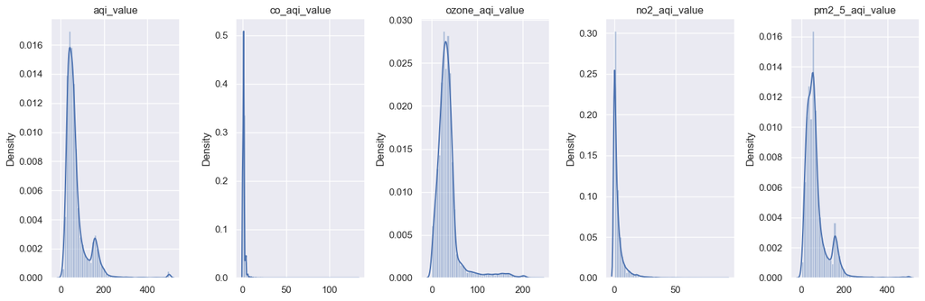

```python
col=[ 'aqi_value', 'co_aqi_value',
       'ozone_aqi_value','no2_aqi_value', 'pm2_5_aqi_value']
fig = plt.figure(figsize=(15,5))

for i in range(len(col)):
    plt.subplot(1,5,i+1)
    plt.title(col[i])
    sns.distplot(data,x=data[col[i]])
plt.tight_layout()
plt.show()
```

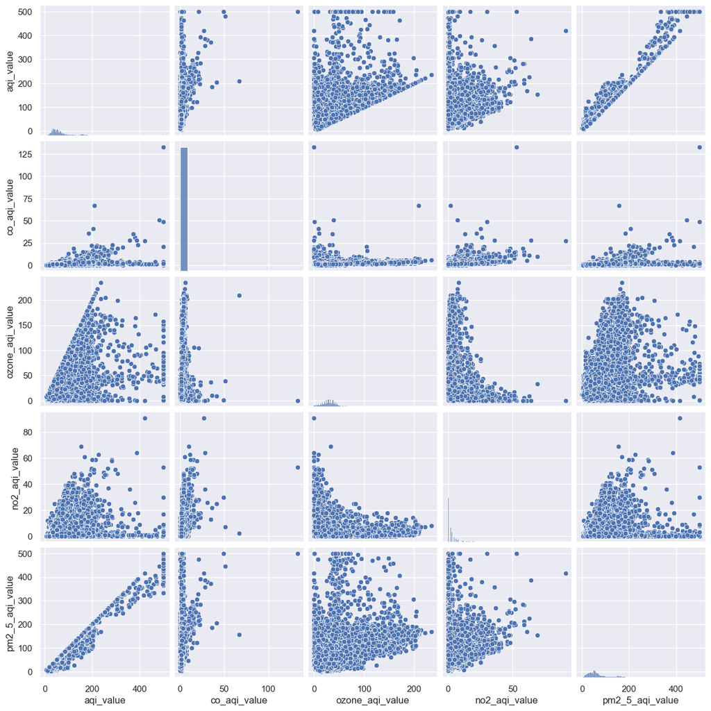

```python
sns.pairplot(data);
```

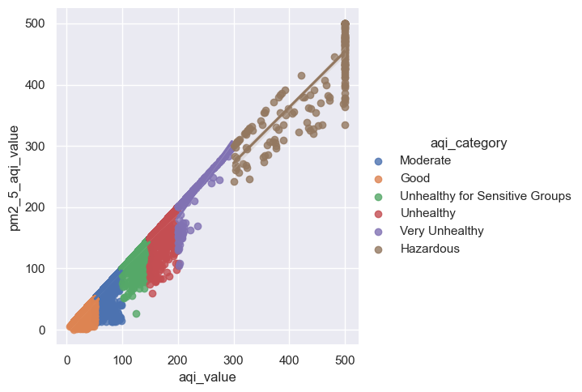

```python
sns.lmplot(data=data,y='pm2_5_aqi_value',x='aqi_value',hue="aqi_category");
```

# Solutions and choices of the Machine Learning Algorithms

# Clustering Problem : find the class of the AQI

**Decision Trees** and **Logistic Regression** are chosen because they are classification algorithms that offer transparency, efficiency, and the ability to handle both numerical and categorical data with interpretability. In contrast, **HDBSCAN** and **K-Means** are clustering algorithms better suited for exploratory data analysis to find natural groupings within data rather than for classifying data points into predefined categories. Hence, we prefer to use Decision Tree and Logistic Regression for our study.

# Regression study : predict the exact value of AQI

For our study we decided to try : **Linear Regression, Ridge Regression, Lasso Regression, Decision Tree Regressor, Random Forest Regressor, Gradient Boosting Regressor.** For our specific study we believe that a subset of features is important => **Lasso regression** should perform well. We have a complex and non linear realationships => **Decision Tree Regressor, Random Forest and Gradient Boosting** should perform well. We set up these choices and try to get the best results we can.

# Experimentation and Discussion of the results

### Part I : Classification

```python
X = data[["co_aqi_value","ozone_aqi_value","pm2_5_aqi_value"]]# We don't use the NO2 Columns value
y = data["aqi_category"]
```

#### DecisionTreeClassifier

```python
X_train, X_test, y_train, y_test = train_test_split(X, y, test_size=0.2, random_state=42)
```

#### Gini criteria

```python
gini = DecisionTreeClassifier(max_depth=2, criterion='gini')
gini.fit(X_train, y_train)
```

```
DecisionTreeClassifier(max_depth=2)
```

```python
y_pred = gini.predict(X_test)

giniAccuracy = accuracy_score(y_test, y_pred)
print('Accuracy of decision tree using Gini: ',giniAccuracy)
```

```
Accuracy of decision tree using Gini:  0.9085872576177285
```

#### Entropy criteria

```python
entropy = DecisionTreeClassifier(max_depth=2, criterion='entropy')
entropy.fit(X_train, y_train)
```

```
DecisionTreeClassifier(criterion='entropy', max_depth=2)
```

```python
y_pred = entropy.predict(X_test)
entropyAccuracy = accuracy_score(y_test, y_pred)
print('Accuracy of decision tree using Gini: ',entropyAccuracy)
```

```
Accuracy of decision tree using Gini:  0.9085872576177285
```

### Observations :

Here we observe that our model with both criteria (Gini vs Entropy) **perform the same**. We need to do a deeper analysis using the k fold cross validation technique to observe some variations between both.

#### Finding the best criteria

```python
def kfoldCrossValidation(X, y, M, k):
    X = np.array(X)
    y = np.array(y)

    kfold = KFold(n_splits=k, shuffle=True, random_state=42)
    scores = []

    for train_index, test_index in kfold.split(X):
        X_train, X_test = X[train_index], X[test_index]
        y_train, y_test = y[train_index], y[test_index]

        M.fit(X_train, y_train)
        y_pred = M.predict(X_test)
        accuracy = accuracy_score(y_test, y_pred)
        scores.append(accuracy)

    return scores

def average_accuracy(scores):
    return sum(scores) / len(scores)
```

```python
gini = DecisionTreeClassifier(max_depth=2, criterion='gini')
print("the result for gini are : ")
k_values = [5, 10, 15]
for k in k_values:
    accuracy_scores = kfoldCrossValidation(X, y, gini, k)
    avg_accuracy = average_accuracy(accuracy_scores)
    print(f'Average Accuracy (k={k}): {avg_accuracy:.10f}')
```

```
the result for gini are :
Average Accuracy (k=5): 0.9106252551
Average Accuracy (k=10): 0.9106254888
Average Accuracy (k=15): 0.9106254954
```

```python
entropy = DecisionTreeClassifier(max_depth=2, criterion='entropy')
print("the result for entropy are : ")
k_values = [5, 10, 15]
for k in k_values:
    accuracy_scores = kfoldCrossValidation(X, y, entropy, k)
    avg_accuracy = average_accuracy(accuracy_scores)
    print(f'Average Accuracy (k={k}): {avg_accuracy:.10f}')
```

```
the result for entropy are :
Average Accuracy (k=5): 0.9106252551
Average Accuracy (k=10): 0.9106254888
Average Accuracy (k=15): 0.9106254954
```

### Observations :

Our analysis shows no significant difference in accuracy between using Gini impurity and entropy for our decision tree model. Given this, we will use **Gini** impurity for its computational efficiency and robustness to noise, making it a practical choice for our current needs.

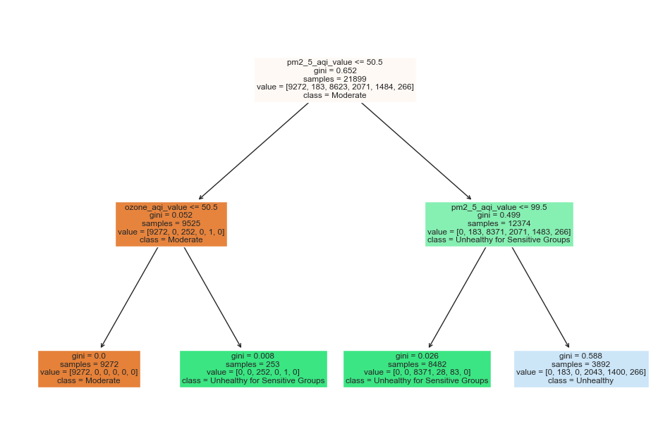

```python
plt.figure(figsize=(12, 8))
plot_tree(gini, filled=True, feature_names=list(X.columns), class_names=list(y.unique()))
plt.show()
```

#### K-Means

```python
gini = DecisionTreeClassifier(max_depth=2, criterion='gini')
gini.fit(X_train, y_train)
impurities = gini.tree_.impurity
children_left = gini.tree_.children_left
children_right = gini.tree_.children_right

is_leaf = np.logical_and(children_left == -1, children_right == -1)
node_impurities = impurities[~is_leaf]
most_impure_node = np.argmax(node_impurities)

children_left[most_impure_node] = -1
children_right[most_impure_node] = -1

node_indices = gini.apply(X_train)
samples_most_impure_node = X_train[node_indices == most_impure_node]
```

```python
k = 2
kmeans = KMeans(n_clusters=k, random_state=42)

kmeans.fit(samples_most_impure_node)
print("Cluster labels for each sample:")
print(kmeans.labels_)
print("\nCluster Centers:")
print(kmeans.cluster_centers_)

unique, counts = np.unique(kmeans.labels_, return_counts=True)
print("\nNumber of samples in each cluster:")
print(dict(zip(unique, counts)))
```

```
Cluster labels for each sample:
[0 0 0 ... 0 0 0]

Cluster Centers:
[[  1.05830389  29.78987885  49.94226401]
 [  3.09514031  65.13928816 170.63312799]]

Number of samples in each cluster:
{0: 15849, 1: 2921}
```

```python
clusters = kmeans.labels_
clustered_data = {}

for cluster_id in np.unique(clusters):
    clustered_data[cluster_id] = X_train[clusters == cluster_id]

cluster_features_summary = {}
for cluster_id, data_points in clustered_data.items():
    cluster_features_summary[cluster_id] = data_points.mean(axis=0)

for cluster_id, features in cluster_features_summary.items():
    print(f"Cluster {cluster_id} feature means:")
    print(features)
```

```
Cluster 0 feature means:
co_aqi_value        1.058300
ozone_aqi_value    29.789766
pm2_5_aqi_value    49.946432
dtype: float64
Cluster 1 feature means:
co_aqi_value         3.095858
ozone_aqi_value     65.152003
pm2_5_aqi_value    170.651832
dtype: float64
```

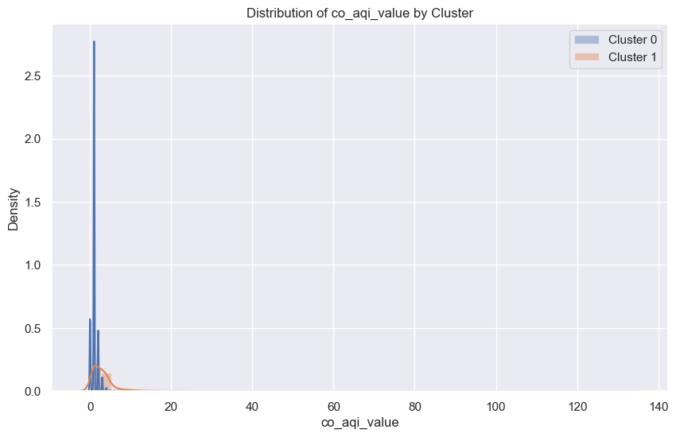

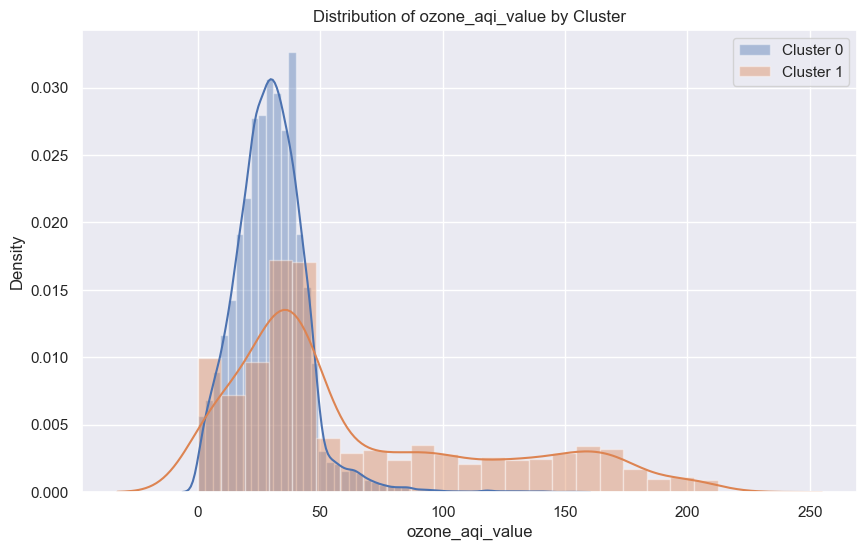

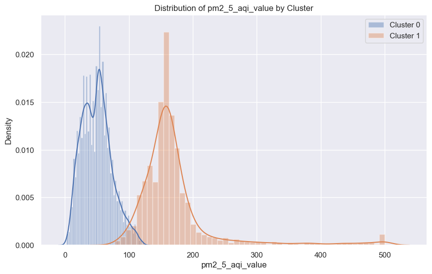

```python
for feature in X.columns:
    plt.figure(figsize=(10, 6))
    for cluster_id in np.unique(clusters):
        sns.distplot(X_train.loc[clusters == cluster_id, feature], label=f'Cluster {cluster_id}')
    plt.title(f'Distribution of {feature} by Cluster')
    plt.legend()
    plt.show()
```

### Observations:

Conclusion:  
We can say that there are fewer countries with high AQI values, and these can be distinguished by higher values in pollutants like PM2.5 or Ozone. However, the CO value does not seem to be a definitive separating criterion between clusters.

#### Doing logistic regression

```python
X_train, X_test, y_train, y_test = train_test_split(X, y, test_size=0.2, random_state=42)

scaler = StandardScaler()
X_train_scaled = scaler.fit_transform(X_train)
X_test_scaled = scaler.transform(X_test)

model = LogisticRegression()
model.fit(X_train_scaled, y_train)
y_pred = model.predict(X_test_scaled)

print("Confusion Matrix:")
print(confusion_matrix(y_test, y_pred))

print("\nClassification Report:")
print(classification_report(y_test, y_pred))

#model coefficients
coefficients = pd.DataFrame(model.coef_[0], index=X.columns, columns=['Coefficient'])
print("\nModel Coefficients:")
print(coefficients)
```

```
Confusion Matrix:
[[1906    0  108    0    0    0]
 [   0   36    0    0    0    6]
 [  61    0 1765    0   11    0]
 [   0    0    0  407    9    3]
 [   1    0   30   30  260    0]
 [   0    1    0   32    0   27]]

Classification Report:
                                precision    recall  f1-score   support

                          Good       0.97      0.95      0.96      2014
                     Hazardous       0.97      0.86      0.91        42
                      Moderate       0.93      0.96      0.94      1837
                     Unhealthy       0.87      0.97      0.92       419
Unhealthy for Sensitive Groups       0.93      0.81      0.87       321
                Very Unhealthy       0.75      0.45      0.56        60

                      accuracy                           0.94      4693
                     macro avg       0.90      0.83      0.86      4693
                  weighted avg       0.94      0.94      0.94      4693


Model Coefficients:
                 Coefficient
co_aqi_value       -1.349245
ozone_aqi_value    -2.703237
pm2_5_aqi_value   -25.408679
```

#### Comparison side by side

```python
X_train, X_test, y_train, y_test = train_test_split(X, y, test_size=0.2, random_state=42)

scaler = StandardScaler()
X_train_scaled = scaler.fit_transform(X_train)
X_test_scaled = scaler.transform(X_test)

gini = DecisionTreeClassifier(max_depth=3, criterion='gini')
gini.fit(X_train_scaled, y_train)

logistic_model = LogisticRegression()
logistic_model.fit(X_train_scaled, y_train)
y_pred_tree = gini.predict(X_test_scaled)
y_pred_logistic = logistic_model.predict(X_test_scaled)

print("Decision Tree Evaluation:")
print("Confusion Matrix:")
print(confusion_matrix(y_test, y_pred_tree))
print("\nClassification Report:")
print(classification_report(y_test, y_pred_tree))

print("Logistic Regression Evaluation:")
print("Confusion Matrix:")
print(confusion_matrix(y_test, y_pred_logistic))
print("\nClassification Report:")
print(classification_report(y_test, y_pred_logistic))
```

```
Decision Tree Evaluation:
Confusion Matrix:
[[2014    0    0    0    0    0]
 [   0    0    0   42    0    0]
 [   0    0 1837    0    0    0]
 [   0    0    0  392   27    0]
 [   0    0    1    0  320    0]
 [   0    0    0   57    3    0]]

Classification Report:
                                precision    recall  f1-score   support

                          Good       1.00      1.00      1.00      2014
                     Hazardous       0.00      0.00      0.00        42
                      Moderate       1.00      1.00      1.00      1837
                     Unhealthy       0.80      0.94      0.86       419
Unhealthy for Sensitive Groups       0.91      1.00      0.95       321
                Very Unhealthy       0.00      0.00      0.00        60

                      accuracy                           0.97      4693
                     macro avg       0.62      0.66      0.64      4693
                  weighted avg       0.95      0.97      0.96      4693

Logistic Regression Evaluation:
Confusion Matrix:
[[1906    0  108    0    0    0]
 [   0   36    0    0    0    6]
 [  61    0 1765    0   11    0]
 [   0    0    0  407    9    3]
 [   1    0   30   30  260    0]
 [   0    1    0   32    0   27]]

Classification Report:
                                precision    recall  f1-score   support

                          Good       0.97      0.95      0.96      2014
                     Hazardous       0.97      0.86      0.91        42
                      Moderate       0.93      0.96      0.94      1837
                     Unhealthy       0.87      0.97      0.92       419
Unhealthy for Sensitive Groups       0.93      0.81      0.87       321
                Very Unhealthy       0.75      0.45      0.56        60

                      accuracy                           0.94      4693
                     macro avg       0.90      0.83      0.86      4693
                  weighted avg       0.94      0.94      0.94      4693
```

[figure not shown]

```python
labels = ['Good', 'Hazardous', 'Moderate', 'Unhealthy', 'Unhealthy for Sensitive Groups', 'Very Unhealthy', 'accuracy']
decision_tree_metrics = [1.00, 0.00, 1.00, 0.80, 0.91, 0.00, 0.97]
logistic_regression_metrics = [0.97, 0.97, 0.93, 0.88, 0.94, 0.77, 0.94]

x = np.arange(len(labels))
width = 0.35

fig, ax = plt.subplots()
rects1 = ax.bar(x - width/2, decision_tree_metrics, width, label='Decision Tree')
rects2 = ax.bar(x + width/2, logistic_regression_metrics, width, label='Logistic Regression')

ax.set_ylabel('Scores')
ax.set_title('Scores by model and class')
ax.set_xticks(x)
ax.set_xticklabels(labels, rotation=45)
ax.legend()

ax.bar_label(rects1, padding=3)
ax.bar_label(rects2, padding=3)

fig.tight_layout()

plt.show()
```

### Observations:

**Decision Tree Evaluation:**

- High accuracy (97%) with perfect precision and recall for 'Good' and 'Moderate' categories.
- Good performance on 'Unhealthy for Sensitive Groups' category (precision: 0.91, recall: 1.00).
- Poor performance on 'Hazardous' and 'Very Unhealthy' categories, failing to correctly classify any instances.
- Overall, the model excels in some categories but completely fails in others, suggesting it might be overfitting to certain classes.

**Logistic Regression Evaluation:**

- Slightly lower overall accuracy (94%) but more balanced performance across categories.
- Better performance in 'Hazardous' and 'Very Unhealthy' categories compared to the Decision Tree, indicating an ability to handle minority classes better.
- High precision and recall for 'Good' and 'Moderate' categories, though slightly lower than the Decision Tree.
- Demonstrates a more consistent performance across different categories.

**Conclusion:**

While the Decision Tree has a higher overall accuracy, its performance is highly skewed towards certain categories, completely failing to classify some classes. This could be a sign of overfitting to the majority classes. In contrast, the Logistic Regression model shows a more balanced performance, effectively classifying minority classes as well.

Given the importance of accurately classifying all categories in air quality index prediction, especially the 'Hazardous' and 'Very Unhealthy' categories for public health implications, the Logistic Regression model is a more suitable choice. Its ability to more uniformly classify across all categories makes it a more reliable model for practical applications in this context.

#### PCA's impact

```
Variance explained for each component: [0.54361258 0.28652558 0.16986184]
Cumulated Variance : [0.54361258 0.83013816 1.        ]
```

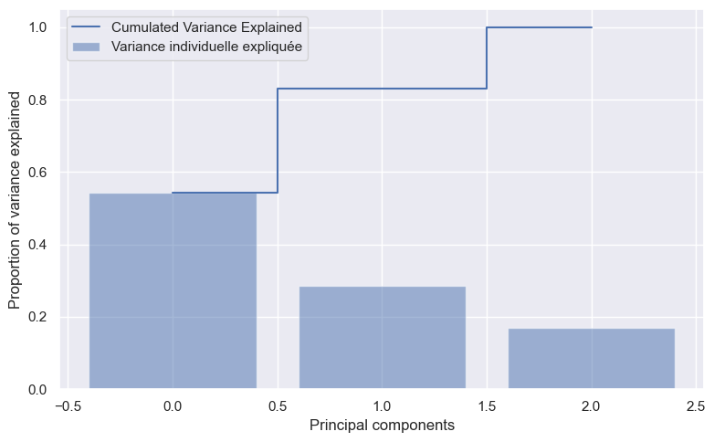

```python
# for PCA we need to standardize the data
scaler = StandardScaler()


#Pipeline
pca = PCA()
pipeline = make_pipeline(scaler, pca)
pipeline.fit(X)
X_pca = pipeline.transform(X)

print('Variance explained for each component:', pca.explained_variance_ratio_)

cumulative_variance = np.cumsum(pca.explained_variance_ratio_)
print('Cumulated Variance :', cumulative_variance)

plt.figure(figsize=(8, 5))
plt.bar(range(len(pca.explained_variance_ratio_)), pca.explained_variance_ratio_, alpha=0.5, align='center',
        label='Variance individuelle expliquée')
plt.step(range(len(cumulative_variance)), cumulative_variance, where='mid',
         label='Cumulated Variance Explained')
plt.ylabel('Proportion of variance explained')
plt.xlabel('Principal components')
plt.legend(loc='best')
plt.tight_layout()
```

```python
pca = PCA(n_components=0.95)

X_train_pca = pca.fit_transform(X_train_scaled)
X_test_pca = pca.transform(X_test_scaled)
logistic_model_pca = LogisticRegression()
logistic_model_pca.fit(X_train_pca, y_train)
y_pred_logistic_pca = logistic_model_pca.predict(X_test_pca)

print("Logistic Regression with PCA Evaluation:")
print("Confusion Matrix:")
print(confusion_matrix(y_test, y_pred_logistic_pca))
print("\nClassification Report:")
print(classification_report(y_test, y_pred_logistic_pca))
```

```
Logistic Regression with PCA Evaluation:
Confusion Matrix:
[[1906    0  108    0    0    0]
 [   0   36    0    0    0    6]
 [  61    0 1765    0   11    0]
 [   0    0    0  407    9    3]
 [   1    0   30   30  260    0]
 [   0    1    0   32    0   27]]

Classification Report:
                                precision    recall  f1-score   support

                          Good       0.97      0.95      0.96      2014
                     Hazardous       0.97      0.86      0.91        42
                      Moderate       0.93      0.96      0.94      1837
                     Unhealthy       0.87      0.97      0.92       419
Unhealthy for Sensitive Groups       0.93      0.81      0.87       321
                Very Unhealthy       0.75      0.45      0.56        60

                      accuracy                           0.94      4693
                     macro avg       0.90      0.83      0.86      4693
                  weighted avg       0.94      0.94      0.94      4693
```

### Part II : Regression

```python
y = data["aqi_value"]
X_train, X_test, y_train, y_test = train_test_split(X, y, test_size=0.2, random_state=42)

scaler = StandardScaler()
X_train_scaled = scaler.fit_transform(X_train)
X_test_scaled = scaler.transform(X_test)
```

```python
models = [
    ("Linear Regression", LinearRegression()),
    ("Ridge Regression", Ridge()),
    ("Lasso Regression", Lasso()),
    ("Decision Tree", DecisionTreeRegressor(random_state=42)),
    ("Random Forest", RandomForestRegressor(random_state=42)),
    ("Gradient Boosting", GradientBoostingRegressor(random_state=42)),
]
# dictionnaires pour stocker les performances et les importances des features
model_performance = {}
feature_importance_dict = {}

for name, model in models:
    model.fit(X_train, y_train)
    y_pred = model.predict(X_test)

    rmse = np.sqrt(mean_squared_error(y_test, y_pred))

    model_performance[name] = rmse

    # to get the most importants variables it depends on the model
    if name in ["Linear Regression", "Ridge Regression", "Lasso Regression"]:
        importance = model.coef_
    else:
        importance = model.feature_importances_
    feature_importance = pd.DataFrame(importance, index=X_train.columns, columns=["Importance"])
    feature_importance = feature_importance.sort_values("Importance", ascending=False)
    feature_importance_dict[name] = feature_importance

model_performance_df = pd.DataFrame(list(model_performance.items()), columns=['Model', 'RMSE'])
print(model_performance_df)
for name, importance in feature_importance_dict.items():
    print(f"Importance des features pour {name}:")
    print(importance.head(10))
    print("\n")
```

```
               Model      RMSE
0  Linear Regression  8.771620
1   Ridge Regression  8.771620
2   Lasso Regression  8.774015
3      Decision Tree  3.861440
4      Random Forest  2.746765
5  Gradient Boosting  3.341810
Importance des features pour Linear Regression:
                 Importance
pm2_5_aqi_value    0.979688
ozone_aqi_value    0.155823
co_aqi_value      -0.023309


Importance des features pour Ridge Regression:
                 Importance
pm2_5_aqi_value    0.979688
ozone_aqi_value    0.155823
co_aqi_value      -0.023309


Importance des features pour Lasso Regression:
                 Importance
pm2_5_aqi_value    0.979200
ozone_aqi_value    0.154667
co_aqi_value      -0.000000


Importance des features pour Decision Tree:
                 Importance
pm2_5_aqi_value    0.980369
ozone_aqi_value    0.018407
co_aqi_value       0.001224


Importance des features pour Random Forest:
                 Importance
pm2_5_aqi_value    0.980794
ozone_aqi_value    0.018112
co_aqi_value       0.001094


Importance des features pour Gradient Boosting:
                 Importance
pm2_5_aqi_value    0.981004
ozone_aqi_value    0.017653
co_aqi_value       0.001343
```

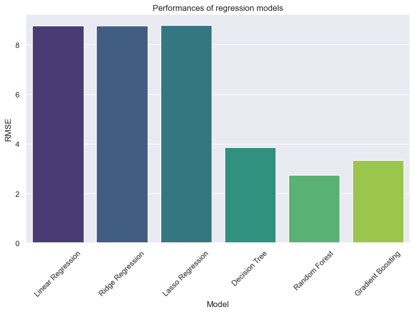

```python
model_performance_df = pd.DataFrame(list(model_performance.items()), columns=['Model', 'RMSE'])

plt.figure(figsize=(10, 6))
sns.barplot(x='Model', y='RMSE', data=model_performance_df, palette='viridis')
plt.title('Performances of regression models')
plt.ylabel('RMSE')
plt.xlabel('Model')
plt.xticks(rotation=45)
plt.show()
```

### Observations:

**RMSE Analysis:**  
RMSE is a measure of the differences between values predicted by a model and the values observed. The lower the RMSE, the better the model's performance.

**Relation to Initial Suppositions:**  
Lasso Regression's performance partially confirms the importance of feature selection. The hypothesis that non-linear models would perform better is strongly confirmed, with Decision Tree, Random Forest, and Gradient Boosting outperforming linear models.

#### Plot the most correlated with PCA

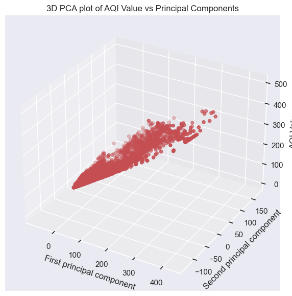

```python
#we reduce the dimensionality to 3 components for 3D plotting
pca_3d = PCA(n_components=3)
X_pca_3d = pca_3d.fit_transform(data[['pm2_5_aqi_value', 'ozone_aqi_value', 'co_aqi_value', 'no2_aqi_value']])

fig_3d = plt.figure(figsize=(10, 7))
ax_3d = fig_3d.add_subplot(111, projection='3d')
ax_3d.scatter(X_pca_3d[:, 0], X_pca_3d[:, 1], data['aqi_value'], c='r', marker='o')

ax_3d.set_xlabel('First principal component')
ax_3d.set_ylabel('Second principal component')
ax_3d.set_zlabel('AQI Value')

plt.title('3D PCA plot of AQI Value vs Principal Components')
plt.show()
```

### Observations :

The 3D PCA plot shows that the Air Quality Index (AQI) is strongly associated with the first principal component, as evidenced by the elongated distribution of data points along this axis. The second principal component has a lesser influence on the data spread. This suggests that the first principal component captures the majority of the information needed to describe the variance in AQI.

#### Gridsearch

```python
from sklearn.model_selection import GridSearchCV
from sklearn.ensemble import RandomForestRegressor
from sklearn.metrics import make_scorer, mean_squared_error
import numpy as np

param_grid = {
    'n_estimators': [30, 40, 50],  # Number of trees in the forest
    'max_depth': [None, 2, 3, 10],  # Maximum depth of the tree
    'min_samples_split': [1, 2, 3, 5, 10],  # Minimum number of samples required to split a node
    'min_samples_leaf': [1, 2, 3, 4],    # Minimum number of samples required at each leaf node
    'bootstrap': [True, False]        # Method of selecting samples for training each tree
}

rf = RandomForestRegressor(random_state=42)
scorer = make_scorer(mean_squared_error, greater_is_better=False)
grid_search = GridSearchCV(estimator=rf, param_grid=param_grid, cv=3, n_jobs=-1, verbose=2)

grid_search.fit(X_train, y_train)
best_params = grid_search.best_params_
print(f"Best parameters: {best_params}")
best_rf = grid_search.best_estimator_
y_pred_best = best_rf.predict(X_test)

rmse_best = np.sqrt(mean_squared_error(y_test, y_pred_best))
print(f"RMSE of the best model: {rmse_best}")
```

```
Fitting 3 folds for each of 480 candidates, totalling 1440 fits
Best parameters: {'bootstrap': True, 'max_depth': None, 'min_samples_leaf': 2, 'min_samples_split': 2, 'n_estimators': 50}
RMSE of the best model: 2.775730360917432
```

# Group Assessement

### General Conclusion:

We have concluent results with 90% accuracy overall and think this could be enough to prove our point that we can predict the AQI Value with less components and therefore **reduce the cost of finding the AQI value in regions of the world**. Furthermore, we think that getting data in more regions of the world could be a way to sensitize the generations to the air quality deplorating over the years.

For our project, we have done several things that we will try to resume to come to a conclusion for our group assessment. We are pretty proud of our pre-processing, that allows good predictions results (**90% accuracy and RMSE of 2.7**). It is the Data inspection and Cleaning that made this possible. We also learned that even though it is not always required, visualizing the data is an important step that makes it clear what to study and in which directions to go.

After understanding the data, we have selected our arguments for the choices of our algorithms, that leads to experimenting with our cleaned dataset. We decided to use Decision Tree and study the entropy, we think we have fathomed its principles and it helped us print the best components (variables) of our study. We have used K-means and done some logistic regression to find our best possible results.

After printing in 3D with our best components with the PCA, we focused our study on the PCA and did our final regression. Then, we did a gridsearch but unfortunately did not conclude to improve our results.

If we could better anything, it could be to do a gridsearch on more algorithms that we might be able to improve. Optimization of the algorithm could be a way to have incredible results (better than what we already have). Also, We think it would be good to link our results to the events that happen in the regions of the world, and also to promote that there still are a lot of places that have very breathable air quality but are underdeveloped for humans social places (we could go back to our example with "La diagonale du vide" in France).

Overall, we are quite content with our project and would like to thank you for reading it.

# Thank you for reading

#### Oscar Pastural - Richard Goudelin

#### Major: DIA (2)

#### Contributions: 50% each student